## Introduction au package data.table

### B.Thieurmel - benoit.thieurmel@datastorm.fr

[figure not shown]

# Introduction

- C’est comme un `data-frame` mais…
- en **plus rapide** dans les requêtes
- et en **plus rapide** dans les calculs !
- avec une **syntaxe particulière**, proche du **SQL** :

```r
DT[i, j, by]

##   R:      i                 j        by
## SQL:  where   select | update  group by
```

**utilise l’objet DT, en sélectionnant les lignes via *i*, en calculant *j*, groupé par *by***

[Vignette d’introduction](https://rawgit.com/wiki/Rdatatable/data.table/vignettes/datatable-intro-vignette.html) : https://rawgit.com/wiki/Rdatatable/data.table/vignettes/datatable-intro-vignette.html

[Wiki](https://github.com/Rdatatable/data.table/wiki/Getting-started) : https://github.com/Rdatatable/data.table/wiki/Getting-started

[cheatsheet](https://s3.amazonaws.com/assets.datacamp.com/img/blog/data+table+cheat+sheet.pdf) : https://s3.amazonaws.com/assets.datacamp.com/img/blog/data+table+cheat+sheet.pdf

# Exemples

```r
require(data.table)

values = rnorm(500000 * 26)
# un data.frame
df <- data.frame(letters = rep(LETTERS, each = 500000), values = values)

# idem, mais avec data.table
dt <- data.table(letters = rep(LETTERS, each = 500000), values = values)
# (=) dt <- as.data.table(df)

print(object.size(df), units ='Mb')
```

```
## 148.8 Mb
```

```r
print(object.size(dt), units ='Mb')
```

```
## 198.4 Mb
```

```r
dim(df)
```

```
## [1] 13000000        2
```

- somme des valeurs pour chaque lettre :

```r
# en utilisant un aggregate
system.time(res1 <- aggregate(values ~ letters, data = df, FUN = sum))
```

```
##    user  system elapsed
##    4.91    0.81    5.82
```

```r
# avec data.table
system.time(res2 <- dt[, sum(values), by = letters])
```

```
##    user  system elapsed
##    0.35    0.05    0.21
```

- Ordonner par les valeurs

```r
# order sur data.frame
system.time(
 res1 <- df[order(df$values), ]
)
```

```
##    user  system elapsed
##    1.89    0.11    2.00
```

```r
# order avec data.table
system.time(
  res2 <- dt[order(values)]
  # = setorder(dt, values)
)
```

```
##    user  system elapsed
##    1.98    0.22    1.58
```

- Faire un subset

```r
# data.frame
system.time(
  res1 <- df[df$letters == "M", ]
)
```

```
##    user  system elapsed
##    0.06    0.02    0.08
```

```r
# data.table
system.time(
  res2 <- dt[letters == "M", ]
)
```

```
##    user  system elapsed
##    0.16    0.01    0.10
```

# Lecture / écriture

- Utilisation de la fonction `fread` pour l’importation de fichier :

```r
# read.table
system.time(
  flights.df <- read.table("flights14.csv", header = T,sep = ",")
)
```

```
##    user  system elapsed
##    0.75    0.12    0.93
```

```r
# fread
system.time(
  flights.dt <- fread("flights14.csv")
)
```

```
##    user  system elapsed
##    0.08    0.01    0.05
```

**Nettement plus performante pour la lecture des fichiers plats que read.table, read.csv, ….**

**La fonction fwrite (>= 1.9.7) existe également pour l’écriture rapide dans un fichier**

# Sélection

- Jeux de données pour les exemples à suivre :

```r
set.seed(1234)

dt <- data.table(group = c("A", "B"),
                 cat = rep(c("C", "D"), each = 5000),
                 value = rnorm(10000),
                 weight = sample(1:10, 10000, replace = TRUE))
head(dt)
```

```
##    group cat      value weight
## 1:     A   C -1.2070657      5
## 2:     B   C  0.2774292      7
## 3:     A   C  1.0844412      1
## 4:     B   C -2.3456977      4
## 5:     A   C  0.4291247      9
## 6:     B   C  0.5060559      8
```

### Sur les lignes

- Pas de rownames dans un **data.table**
- On peut utiliser les indices numériques (*comme avec les data.frame*)
- Ou faire un subset rapide en utilisant les noms de colonnes

```r
dt[1:2, ]
dt[c(1,5)] # pas obliger de mettre une virgule...
dt[weight > 8, ] # pas besoin de "" ou '' pour les noms
dt[order(value)]
```

```r
dt[1:2, ]
```

```
##    group cat      value weight
## 1:     A   C -1.2070657      5
## 2:     B   C  0.2774292      7
```

### Sur les colonnes

- Par défaut (historiquement), avec les noms de colonnes **sans quote** dans une liste
- Sélection numérique **possible** avec **data.table** >= 1.9.7, **impossible avant**
- **avec quote** : **data.table** >= 1.9.7 ou avec l’utilisation explicite de l’option `with = FALSE`

```r
dt[, c(1, 3)] ## marche maintenant !
dt[, value] ## vecteur
dt[, list(value)] ## data.table
dt[, "value"] ## data.table
# plusieurs colonnes
dt[, list(group, value)] ## data.table
dt[, .(group, value)] ## raccourci (. == list)
dt[, c("group", "value"), with = FALSE] ## avec des "noms"
## renommage
dt[, list(mygroup = group, myvalue = value)]
```

```
##    mygroup    myvalue
## 1:       A -1.2070657
## 2:       B  0.2774292
```

# Manipulation

### Ajout/Suppression de colonnes

- via l’opérateur `:=` (éviter `cbind`, peu performant)
- retourne le résultat de façon *invisible*
- suppression avec `NULL`

```r
dt[, tvalue := trunc(value)]
```

```r
dt[1:2]
```

```
##    group cat      value weight tvalue
## 1:     A   C -1.2070657      5     -1
## 2:     B   C  0.2774292      7      0
```

- plusieurs colonnes

```r
dt[, c("tvalue", "rvalues") := list(trunc(value), round(value ,2))]
dt[, ':=' (tvalue = trunc(value), rvalue = round(value ,2))] # alternative
```

```r
dt[1:2]
```

```
##    group cat      value weight tvalue rvalues
## 1:     A   C -1.2070657      5     -1   -1.21
## 2:     B   C  0.2774292      7      0    0.28
```

- suppression

```r
dt[, rvalues := NULL]
```

```r
dt[1:2]
```

```
##    group cat      value weight tvalue
## 1:     A   C -1.2070657      5     -1
## 2:     B   C  0.2774292      7      0
```

### Modification de colonnes

- via l’opérateur `:=`, et donc avec un **nom de colonne existante**…

```r
dt <- dt[, tvalue := tvalue + 10]
```

```r
dt[1:2]
```

```
##    group cat      value weight tvalue
## 1:     A   C -1.2070657      5      9
## 2:     B   C  0.2774292      7     10
```

```r
# sur un sous-ensemble de ligne uniquement :
dt <- dt[group == "A", tvalue := tvalue + 100]
```

```r
dt[1:2]
```

```
##    group cat      value weight tvalue
## 1:     A   C -1.2070657      5    109
## 2:     B   C  0.2774292      7     10
```

### Calculs

- On peut effectuer tous les calculs directement

```r
dt[, sum(value)] # un vecteur
```

```
## [1] 61.15893
```

```r
dt[, list(sum(value))] # un data.table
```

```
##          V1
## 1: 61.15893
```

```r
# sous-population + calculs multiples + renommage
dt[group == "B", list(somme = sum(value), moyenne = mean(value))]
```

```
##        somme    moyenne
## 1: -75.82302 -0.0151646
```

- on peut enchainer plusieurs expressions avec des accolades

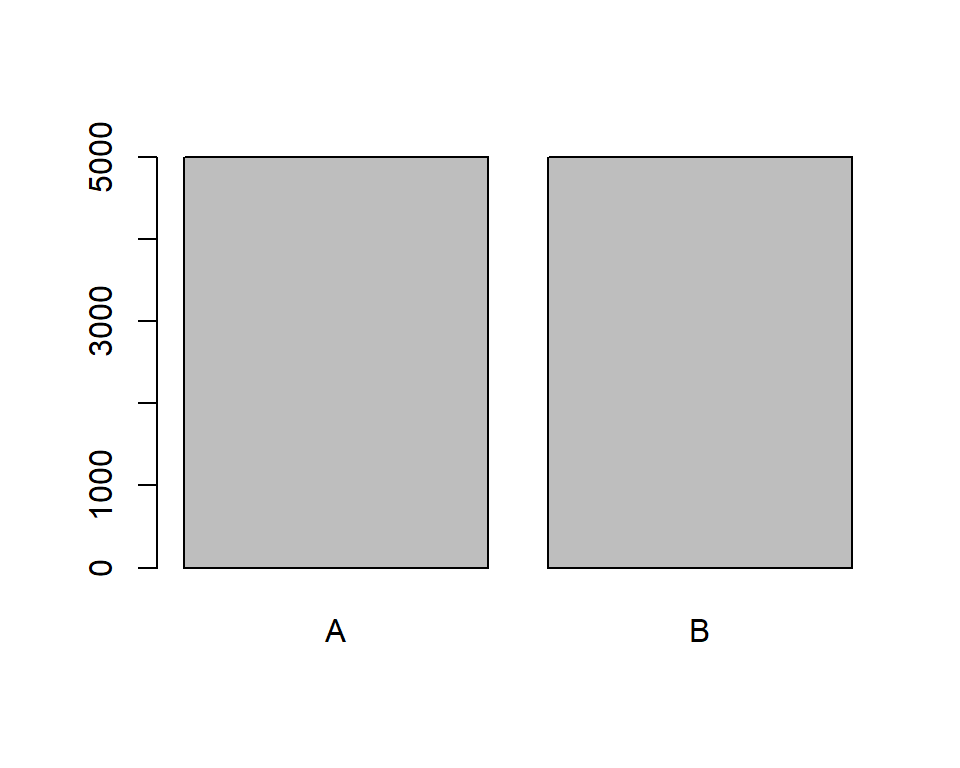

```r
dt[, {t = table(group)
  barplot(t)
  NULL}]
```

### Aggrégation par niveaux

- utilisation du `by`, avec `list()`, ou bien un vecteur de noms

```r
# par une variable
dt[, sum(value), by = group] # dt[, sum(value), by = "group"]
```

```
##    group        V1
## 1:     A 136.98194
## 2:     B -75.82302
```

```r
# par plusieurs variables et calculs multiples
dt[, list(somme = sum(value), moy = mean(value)), by = list(group, cat)]
```

```
##    group cat      somme           moy
## 1:     A   C   2.125355  0.0008501418
## 2:     B   C -33.898836 -0.0135595342
## 3:     A   D 134.856590  0.0539426361
## 4:     B   D -41.924180 -0.0167696718
```

```r
# dt[, .(somme = sum(value), moy = mean(value)), by = c("group", "cat")]
```

- On peut aussi utiliser des expressions dans le `by`

```r
# somme des valeurs, avec un poids inférieur ou supérieur à 5, par groupe
dt[, sum(value), by = list(group, weight > 5)]
```

```
##    group weight        V1
## 1:     A  FALSE  58.74680
## 2:     B   TRUE -38.23590
## 3:     B  FALSE -37.58711
## 4:     A   TRUE  78.23514
```

- `by` garde l’ordre d’apparition des niveaux
- `keyby` ordonne le résultat

```r
dt[, .(somme = sum(value), moy = mean(value)), keyby = list(group, cat)]
```

```
##    group cat      somme           moy
## 1:     A   C   2.125355  0.0008501418
## 2:     A   D 134.856590  0.0539426361
## 3:     B   C -33.898836 -0.0135595342
## 4:     B   D -41.924180 -0.0167696718
```

- Et affecter le/les résultats par niveaux aux données de départ

```r
# nouvelle colonne, avec la moyenne dans la categorie
dt[, mean_cat := mean(value), by = list(cat)]
dt
```

```
##        group cat       value weight tvalue     mean_cat
##     1:     A   C -1.20706575      5    109 -0.006354696
##     2:     B   C  0.27742924      7     10 -0.006354696
##     3:     A   C  1.08444118      1    111 -0.006354696
##     4:     B   C -2.34569770      4      8 -0.006354696
##     5:     A   C  0.42912469      9    110 -0.006354696
##    ---
##  9996:     B   D  0.01973902      7     10  0.018586482
##  9997:     A   D -2.12674529      6    108  0.018586482
##  9998:     B   D -0.05022201      9     10  0.018586482
##  9999:     A   D -0.23817408      7    110  0.018586482
## 10000:     B   D  0.77640531      7     10  0.018586482
```

### L’opérateur .N : retourne le nombre de ligne

```r
dt[, .N] # nombre de lignes des données
```

```
## [1] 10000
```

```r
# subset + renommage + tri
dt[weight > 5, list(rows = .N), by = list(group, cat)][order(-rows)]
```

```
##    group cat rows
## 1:     A   D 1288
## 2:     B   D 1260
## 3:     A   C 1255
## 4:     B   C 1240
```

### Graphiques, modèles, …

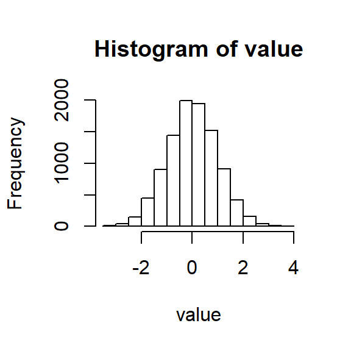

```r
dt[, {hist(value);NULL}] # suivi d'un NULL, sinon print dans la console...
```

```r
# graphiques par groupe
par(ask=TRUE)
dt[, hist(value), by = list(group, cat)]
```

### Chaînage

- Les opérations sur un **data.table** retournent (en général) un **data.table**
- On peut donc enchaîner les opérations **[…]**

```r
# somme et moyenne des valeurs pour group et cat
# ordonné par somme
dt[, list(somme = sum(value), moy = mean(value)), by = list(group, cat)][order(somme)]
```

```
##    group cat      somme           moy
## 1:     B   D -41.924180 -0.0167696718
## 2:     B   C -33.898836 -0.0135595342
## 3:     A   C   2.125355  0.0008501418
## 4:     A   D 134.856590  0.0539426361
```

# .SD

- **.SD** contient toutes les colonnes, **à l’exception de celle(s) utilisée(s)** dans le `by`

```r
# regardons cela...
dt[1:4, print(.SD), by = .(group)]
```

```
##    cat     value weight tvalue     mean_cat
## 1:   C -1.207066      5    109 -0.006354696
## 2:   C  1.084441      1    111 -0.006354696
##    cat      value weight tvalue     mean_cat
## 1:   C  0.2774292      7     10 -0.006354696
## 2:   C -2.3456977      4      8 -0.006354696
```

```
## Empty data.table (0 rows and 1 cols): group
```

- pas utiliser nécessairement avec un `by`
- on peut l’utiliser pour **faire des calculs sur plusieurs colonnes**

```r
dt[, lapply(.SD, mean), by = .(group, cat)]
```

```
##    group cat         value weight   tvalue     mean_cat
## 1:     A   C  0.0008501418 5.4980 109.9960 -0.006354696
## 2:     B   C -0.0135595342 5.4468   9.9920 -0.006354696
## 3:     A   D  0.0539426361 5.5848 110.0348  0.018586482
## 4:     B   D -0.0167696718 5.5268   9.9840  0.018586482
```

- une sous-sélection de colonnes est possible avec **.SDcols**

```r
dt[, lapply(.SD, mean), by = .(group), .SDcols = "value"] # avec un/des nom(s)
```

```
##    group       value
## 1:     A  0.02739639
## 2:     B -0.01516460
```

```r
# ou des indices : dt[, lapply(.SD, mean), by = .(group), .SDcols = 3]
```

# les clés

- **data.table** dispose d’un système de clés
- le tableau est alors ordonné par les clés
- les subsets sur les clés seront plus performants
- argument *key* dans la fonction **data.table**
- ou `setkey` avec des noms de colonnes sans quote
- `setkeyv` avec quote
- `key` pour connaitre les clés de la table

```r
set.seed(1234)
values = rnorm(384616 * 26)
dt <- data.table(letters = rep(LETTERS, each = 384616), group = letters[1:16], values = values)
```

- la sélection est plus rapide, et l’appel simplifié, **par défaut dans l’ordre des clés**

```r
setkey(dt, NULL)
system.time(
  dt[group == "f", ]
)
```

```
##    user  system elapsed
##    0.23    0.07    0.19
```

```r
setkey(dt, group)
system.time(
  dt["f", ]
)
```

```
##    user  system elapsed
##    0.01    0.00    0.02
```

- clés multiples : sélection via une *liste*

```r
setkey(dt, NULL)
system.time(
  dt[letters == "M" & group == "f", ]
)
```

```
##    user  system elapsed
##    0.25    0.01    0.14
```

```r
setkey(dt, letters, group)
system.time(
  dt[list("M", "f"), ]
)
```

```
##    user  system elapsed
##       0       0       0
```

- clés et valeurs multiples : sélection via une *liste*, et des *vecteurs* de valeurs

```r
setkey(dt, NULL)
system.time(
  dt[letters == "M" & group %in% c("f", "g"), ]
)
```

```
##    user  system elapsed
##    0.17    0.08    0.16
```

```r
setkey(dt, letters, group)
system.time(
  dt[list("M", c("f", "g")), ]
)
```

```
##    user  system elapsed
##       0       0       0
```

# Transformation

- Via deux fonctions `melt`, et `dcast`, basées sur celles présentes dans le package **reshape2**

```r
# les données
dt <- data.table(airquality)
dt
```

```
##      Ozone Solar.R Wind Temp Month Day
##   1:    41     190  7.4   67     5   1
##   2:    36     118  8.0   72     5   2
##   3:    12     149 12.6   74     5   3
##   4:    18     313 11.5   62     5   4
##   5:    NA      NA 14.3   56     5   5
##  ---
## 149:    30     193  6.9   70     9  26
## 150:    NA     145 13.2   77     9  27
## 151:    14     191 14.3   75     9  28
## 152:    18     131  8.0   76     9  29
## 153:    20     223 11.5   68     9  30
```

### melt

```r
res_melt <- melt(data = dt, id = c("Month", "Day"))
res_melt
```

```
##      Month Day variable value
##   1:     5   1    Ozone    41
##   2:     5   2    Ozone    36
##   3:     5   3    Ozone    12
##   4:     5   4    Ozone    18
##   5:     5   5    Ozone    NA
##  ---
## 608:     9  26     Temp    70
## 609:     9  27     Temp    77
## 610:     9  28     Temp    75
## 611:     9  29     Temp    76
## 612:     9  30     Temp    68
```

### dcast

```r
res_dcast <- dcast.data.table(data = res_melt, Month + Day ~ variable)
res_dcast
```

```
##      Month Day Ozone Solar.R Wind Temp
##   1:     5   1    41     190  7.4   67
##   2:     5   2    36     118  8.0   72
##   3:     5   3    12     149 12.6   74
##   4:     5   4    18     313 11.5   62
##   5:     5   5    NA      NA 14.3   56
##  ---
## 149:     9  26    30     193  6.9   70
## 150:     9  27    NA     145 13.2   77
## 151:     9  28    14     191 14.3   75
## 152:     9  29    18     131  8.0   76
## 153:     9  30    20     223 11.5   68
```

# Merge

**data.table** possède sa fonction `merge`, identique à celle de base, mais beaucoup plus performante

```r
dim(dt)
```

```
## [1] 100000      4
```

```r
n_groups <- dt[, .N, by = list(group, cat)]
# data.table
system.time({merge(dt, n_groups, by = c("group", "cat"))})
```

```
##    user  system elapsed
##    0.01    0.00    0.02
```

```r
# data.frame
df <- as.data.frame(dt) ; df_n_groups <- as.data.frame(n_groups)
system.time({merge(df, df_n_groups, by = c("group", "cat"))})
```

```
##    user  system elapsed
##    0.42    0.00    0.42
```

# copy et gestion de la mémoire

un objet **data.table** peut se voir comme un pointeur mémoire, et il ne possède pas les mêmes propriétés que la plupart des autres objets **R**, notamment lors de l’affectation à une nouvelle variable :

**exemple sur un data.frame**

```r
df <- data.frame(x = 1, y = 1)
df2 <- df # nouvelle affectation
df2$y <- 2
df
```

```
##   x y
## 1 1 1
```

```r
df2
```

```
##   x y
## 1 1 2
```

**seulement df2 a été modifié**

**exemple sur un data.table**

```r
dt <- data.table(x = 1, y = 1)
dt2 <- dt # nouvelle affectation
dt2[, y := 2]
dt
```

```
##    x y
## 1: 1 2
```

```r
dt2
```

```
##    x y
## 1: 1 2
```

**dt2 et dt ont été modifiés. Pour empêcher cela, il faut explicitement copier dt :**

```r
dt2 <- copy(dt) # nouvelle affectation et copie
```

# Quelques fonctions utiles

- `setcolorder` : ré-ordonnancement des colonnes
- `setorder` & `setorderv`: tri de la table
- `subset` : syntaxe **R** base pour un sous-ensemble de données
- `shift` : lead/lag de colonnes
- `IDate` & `IDateTime`: gestion et traitement efficace des dates/heures
- `rbindlist` : concaténation de data.table
- `tables` : informations sur les tables existantes
- `copy` : copie mémoire d’une table

# Le package dplyr : une alternative à data.table

Il y a actuellement deux packages majeurs pour le traitement efficace de données : le package **data.table** et le package **dplyr**. Ils se distinguent essentiellement par leur syntaxe :

```r
# data.table
dt[group == "A", list(s_value = sum(value)), by = list(group, cat)]

# dplyr
dt %>%
  group_by(group, cat) %>%
  filter(group == "A") %>%
  summarise(s_value = sum(value))
```

Plus d’informations sur **dplyr** : http://dplyr.tidyverse.org/

# Pour aller plus loin

- [Vignette d’introduction](https://rawgit.com/wiki/Rdatatable/data.table/vignettes/datatable-intro-vignette.html) : https://rawgit.com/wiki/Rdatatable/data.table/vignettes/datatable-intro-vignette.html
- [Semantique](https://rawgit.com/wiki/Rdatatable/data.table/vignettes/datatable-reference-semantics.html) : https://rawgit.com/wiki/Rdatatable/data.table/vignettes/datatable-reference-semantics.html
- [Clés](https://rawgit.com/wiki/Rdatatable/data.table/vignettes/datatable-keys-fast-subset.html) : https://rawgit.com/wiki/Rdatatable/data.table/vignettes/datatable-keys-fast-subset.html
- [Transformations](https://rawgit.com/wiki/Rdatatable/data.table/vignettes/datatable-reshape.html) : https://rawgit.com/wiki/Rdatatable/data.table/vignettes/datatable-reshape.html